# Google Trends

[figure not shown]

Google Trends Anaih Pastana Pereira 2023-04-17

## Introdução

- Essa é uma análise dos dados do Google Trends sobre o PicPay utilizando **R**. Esse relatório é gerado automaticamente a cada semana, utilizando a ferramenta **GitHub Actions** e *hosteando* no **GitHub Pages**.

## Pacotes

```r
library(gtrendsR)
library(dplyr)
library(ggplot2)
library(wordcloud2)
library(stringr)
library(RColorBrewer)
library(ggrepel)
```

## Dados Google Trends

- O Google Trends é uma ferramenta que permite acompanhar a evolução do número de buscas por uma determinada palavra-chave ao longo do tempo. Nesse caso, acompanhamos a evolução da busca pela palavra **picpay** nos últmos 30 dias.

```r
dados_gt <- gtrends(keyword = "picpay",geo = "BR",time = "today 1-m")
```

## Interesse de pesquisa ao longo do tempo

- Os números representam o interesse de pesquisa relativo ao ponto mais alto no gráfico de um dado período.

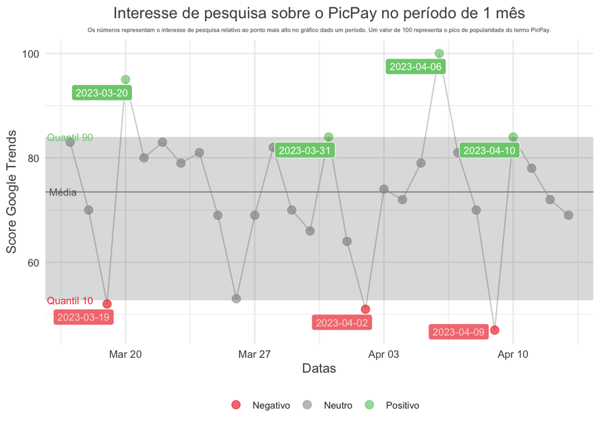

```r
sig <- 0.01  #colocando a significancia para o intervalo de confianca

df_cal <-  #Gerando um dataframe com as medidas para utilizar no grafico
dados_gt$interest_over_time %>%
  summarise(media=mean(hits),
            ic_inf=media-(qt(1-(sig/2),nrow(.))*(sd(hits)/sqrt(nrow(.)))),
            ic_sup=media+(qt(1-(sig/2),nrow(.))*(sd(hits)/sqrt(nrow(.)))),
            q_90=quantile(hits,0.90),
            q_10=quantile(hits,0.10),
            min_date=min(date))


dados_gt$interest_over_time %>%    #Grafico com o interesse a longo do tempo
  mutate(flg_destaque=case_when(hits>=df_cal$q_90 ~ "Positivo",
                                hits<=df_cal$q_10 ~ "Negativo",
                                TRUE ~ "Neutro"),
         flg_sup=case_when(hits>=df_cal$q_90 ~ as.character(date),
                                TRUE ~ NA_character_),
         flg_inf=case_when(hits<=df_cal$q_10 ~ as.character(date),
                                TRUE ~ NA_character_) )%>%
  ggplot(aes(date,hits))+
  geom_line(col="lightgray")+
  geom_point(aes(col=flg_destaque),cex=3,alpha=0.7)+
  scale_color_manual(values=c('brown2','gray66', 'palegreen3'))+
  geom_hline(yintercept = df_cal$media, color="darkgray")+
  annotation_raster(alpha("gray30", .2),
    xmin = -Inf, xmax = Inf,
    ymin=df_cal$q_10 , ymax=df_cal$q_90) +
  theme_minimal()+
  geom_label_repel(aes(label = flg_sup, fill = flg_destaque), color = 'white',
                   size = 3,show.legend = F)+
  geom_label_repel(aes(label = flg_inf, fill = flg_destaque), color = 'white',
                   size = 3,show.legend = F,alpha=0.7)+
  scale_fill_manual(values = c('brown2','gray66', 'palegreen3'))+
  theme(legend.position = "bottom",
        legend.text = element_text(size = 8, colour = "gray20"),
        legend.title = element_blank())+
  annotate(geom="text", x=df_cal$min_date,
           y=c(df_cal$q_90 , df_cal$q_10 , df_cal$media),
           label=c("Quantil 90","Quantil 10","Média     "),
           color=c('palegreen3','brown2','gray40'),size=3,hjust=0.5) +
  ggtitle(label="Interesse de pesquisa sobre o PicPay no período de 1 mês",
          subtitle = "Os números representam o interesse de pesquisa relativo ao ponto mais alto no gráfico dado um período. Um valor de 100 representa o pico de popularidade do termo PicPay.")+
    xlab("Datas") +
  ylab("Score Google Trends")+
  theme(plot.title = element_text(hjust=0.5,colour = "gray30"),
        plot.subtitle = element_text(hjust=0.5,colour = "gray30",size=5),
        axis.title.x = element_text(colour = "gray30"),
        axis.title.y = element_text(colour = "gray30"),
        axis.text.x = element_text(colour = "gray30"),
        axis.text.y = element_text(colour = "gray30"))
```

No gráfico acima temos uma linha que representa a média do Score de Interesse, a área em cinza representa o intervalo entre os quantis 10 e 90 do score. Os pontos em verde representam os dias com mais interesse nas buscas e em vermelho os dias com menos interesse.

## Wordcloud

- o Wordcloud foi feito a partir das principais consultas feitas pelos usuarios que também pesquisaram a o termo “picpay”.

  A pontuação está em uma escala relativa, em que 100 é a consulta mais pesquisada; 50 é a consulta feita com metade dessa frequência etc.

```r
cria_wordcloud <- function(df){
  green_fun=colorRampPalette(brewer.pal(9,"Greens")) #Escolhendo a cor
  df %>%
  mutate(subject=as.numeric(subject),   #Arrumando aas palavras/ termos usados
         value=tolower(value) ,
         value=str_remove_all(value, pattern = "picpay|pic pay"),
         value=str_trim(value,side = "both"),
         value=str_remove_all(value, pattern = "do| de| da| o| a| no| na| e"),
         value=iconv(value,from = "UTF-8",to="ASCII//TRANSLIT"),
         value=str_trim(value,side="both"),
         value=str_squish(value)) %>%
  filter(value!="") %>%
  group_by(value) %>%
  summarise(freq=sum(subject)) %>%
  ungroup() %>%
  setNames(c("word","freq")) %>%
  wordcloud2(color=rev(green_fun(nrow(.))))
}

  dados_gt$related_queries %>%    #Chamando a função que gera wordcloud
  filter(related_queries=="top") %>%
  cria_wordcloud()
```

[interactive chart not shown]